Выполнил студент БВТ2002 Митрофанов Алексей

# Открытый курс по машинному обучению.

Автор материала: программист-исследователь Mail.ru Group, старший преподаватель Факультета Компьютерных Наук ВШЭ Юрий Кашницкий. Материал распространяется на условиях лицензии [Creative Commons CC BY-NC-SA 4.0](https://creativecommons.org/licenses/by-nc-sa/4.0/). Можно использовать в любых целях (редактировать, поправлять и брать за основу), кроме коммерческих, но с обязательным упоминанием автора материала.

# Тема 1. Первичный анализ данных с Pandas

## Практическое задание. Анализ данных пассажиров "Титаника"

**Заполните код в клетках (где написано "Ваш код здесь")

```python
import numpy as np
import pandas as pd
import matplotlib.pyplot as plt
import math as m
%matplotlib inline
```

**Считаем данные из файла в память в виде объекта Pandas.DataFrame**

```python
data = pd.read_csv('titanic_train.csv',
                  index_col='PassengerId')
```

**Данные представлены в виде таблицы. Посмотрим на первые 5 строк:**

```python
data.head(5)
```

| PassengerId | Survived | Pclass | Name | Sex | Age | SibSp | Parch | Ticket | Fare | Cabin | Embarked |
| --- | --- | --- | --- | --- | --- | --- | --- | --- | --- | --- | --- |
| 1 | 0 | 3 | Braund, Mr. Owen Harris | male | 22.0 | 1 | 0 | A/5 21171 | 7.2500 | NaN | S |
| 2 | 1 | 1 | Cumings, Mrs. John Bradley (Florence Briggs Th... | female | 38.0 | 1 | 0 | PC 17599 | 71.2833 | C85 | C |
| 3 | 1 | 3 | Heikkinen, Miss. Laina | female | 26.0 | 0 | 0 | STON/O2. 3101282 | 7.9250 | NaN | S |
| 4 | 1 | 1 | Futrelle, Mrs. Jacques Heath (Lily May Peel) | female | 35.0 | 1 | 0 | 113803 | 53.1000 | C123 | S |
| 5 | 0 | 3 | Allen, Mr. William Henry | male | 35.0 | 0 | 0 | 373450 | 8.0500 | NaN | S |

```python
data.describe()
```

|  | Survived | Pclass | Age | SibSp | Parch | Fare |
| --- | --- | --- | --- | --- | --- | --- |
| count | 891.000000 | 891.000000 | 714.000000 | 891.000000 | 891.000000 | 891.000000 |
| mean | 0.383838 | 2.308642 | 29.699118 | 0.523008 | 0.381594 | 32.204208 |
| std | 0.486592 | 0.836071 | 14.526497 | 1.102743 | 0.806057 | 49.693429 |
| min | 0.000000 | 1.000000 | 0.420000 | 0.000000 | 0.000000 | 0.000000 |
| 25% | 0.000000 | 2.000000 | 20.125000 | 0.000000 | 0.000000 | 7.910400 |
| 50% | 0.000000 | 3.000000 | 28.000000 | 0.000000 | 0.000000 | 14.454200 |
| 75% | 1.000000 | 3.000000 | 38.000000 | 1.000000 | 0.000000 | 31.000000 |
| max | 1.000000 | 3.000000 | 80.000000 | 8.000000 | 6.000000 | 512.329200 |

**Для примера отберем пассажиров, которые сели в Cherbourg (Embarked=C) и заплатили более 200 у.е. за билет (fare > 200).**

Убедитесь, что Вы понимаете, как эта конструкция работает.  
Если нет – посмотрите, как вычисляется выражение в квадратных в скобках.

```python
data[(data['Embarked'] == 'C') & (data.Fare > 200)].head()
```

| PassengerId | Survived | Pclass | Name | Sex | Age | SibSp | Parch | Ticket | Fare | Cabin | Embarked |
| --- | --- | --- | --- | --- | --- | --- | --- | --- | --- | --- | --- |
| 119 | 0 | 1 | Baxter, Mr. Quigg Edmond | male | 24.0 | 0 | 1 | PC 17558 | 247.5208 | B58 B60 | C |
| 259 | 1 | 1 | Ward, Miss. Anna | female | 35.0 | 0 | 0 | PC 17755 | 512.3292 | NaN | C |
| 300 | 1 | 1 | Baxter, Mrs. James (Helene DeLaudeniere Chaput) | female | 50.0 | 0 | 1 | PC 17558 | 247.5208 | B58 B60 | C |
| 312 | 1 | 1 | Ryerson, Miss. Emily Borie | female | 18.0 | 2 | 2 | PC 17608 | 262.3750 | B57 B59 B63 B66 | C |
| 378 | 0 | 1 | Widener, Mr. Harry Elkins | male | 27.0 | 0 | 2 | 113503 | 211.5000 | C82 | C |

**Можно отсортировать этих людей по убыванию платы за билет.**

```python
data[(data['Embarked'] == 'C') &
     (data['Fare'] > 200)].sort_values(by='Fare',
                               ascending=False).head()
```

| PassengerId | Survived | Pclass | Name | Sex | Age | SibSp | Parch | Ticket | Fare | Cabin | Embarked |
| --- | --- | --- | --- | --- | --- | --- | --- | --- | --- | --- | --- |
| 259 | 1 | 1 | Ward, Miss. Anna | female | 35.0 | 0 | 0 | PC 17755 | 512.3292 | NaN | C |
| 680 | 1 | 1 | Cardeza, Mr. Thomas Drake Martinez | male | 36.0 | 0 | 1 | PC 17755 | 512.3292 | B51 B53 B55 | C |
| 738 | 1 | 1 | Lesurer, Mr. Gustave J | male | 35.0 | 0 | 0 | PC 17755 | 512.3292 | B101 | C |
| 312 | 1 | 1 | Ryerson, Miss. Emily Borie | female | 18.0 | 2 | 2 | PC 17608 | 262.3750 | B57 B59 B63 B66 | C |
| 743 | 1 | 1 | Ryerson, Miss. Susan Parker "Suzette" | female | 21.0 | 2 | 2 | PC 17608 | 262.3750 | B57 B59 B63 B66 | C |

**Пример создания признака.**

```python
def age_category(age):
    '''
    < 30 -> 1
    >= 30, <55 -> 2
    >= 55 -> 3
    '''
    if age < 30:
        return 1
    elif age < 55:
        return 2
    else:
        return 3
```

```python
age_categories = [age_category(age) for age in data.Age]
```

```python
data['Age_category'] = age_categories
```

**Другой способ – через `apply`.**

```python
data['Age_category'] = data['Age'].apply(age_category)
```

```python
data['Age_category'].value_counts()
```

```
1    384
2    288
3    219
Name: Age_category, dtype: int64
```

**1. Сколько мужчин / женщин находилось на борту?**

- 412 мужчин и 479 женщин
- 314 мужчин и 577 женщин
- 479 мужчин и 412 женщин
- **577 мужчин и 314 женщин** ✅

```python
data['Sex'].value_counts()
```

```
male      577
female    314
Name: Sex, dtype: int64
```

**2. Выведите распределение переменной `Pclass` (социально-экономический статус) и это же распределение, только для мужчин / женщин по отдельности. Сколько было мужчин 2-го класса?**

- 104
- **108** ✅
- 112
- 125

```python
import seaborn as sns
sns.set()
```

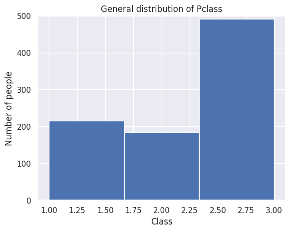

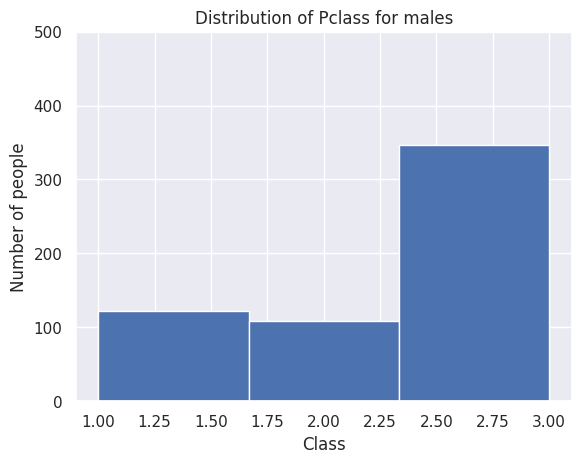

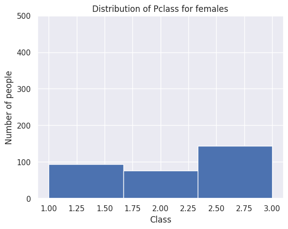

```python
# Ваш код здесь
data.hist(column='Pclass', bins=3)
ax = plt.gcf().gca()
ax.set_title('General distribution of Pclass')
ax.set_xlabel('Class')
ax.set_ylabel('Number of people')
ax.set_ybound(upper = 500)

data[data['Sex'] == 'male'].hist(column='Pclass', bins=3)
ax = plt.gcf().gca()
ax.set_title('Distribution of Pclass for males')
ax.set_xlabel('Class')
ax.set_ylabel('Number of people')
ax.set_ybound(upper = 500)

data[data['Sex'] == 'female'].hist(column='Pclass', bins=3)
ax = plt.gcf().gca()
ax.set_title('Distribution of Pclass for females')
ax.set_xlabel('Class')
ax.set_ylabel('Number of people')
ax.set_ybound(upper = 500)
plt.show()
```

```python
print( "Males of Pclass 2:", data[(data['Sex'] == 'male') & (data['Pclass'] == 2)].shape[0] )
```

```
Males of Pclass 2: 108
```

**3. Каковы медиана и стандартное отклонение платежей (`Fare`)? Округлите до 2 десятичных знаков.**

- **Медиана – 14.45, стандартное отклонение – 49.69** ✅
- Медиана – 15.1, стандартное отклонение – 12.15
- Медиана – 13.15, стандартное отклонение – 35.3
- Медиана – 17.43, стандартное отклонение – 39.1

```python
print("Median: ", round(data['Fare'].median(), 2))
print("Std. deviation: ", round(data['Fare'].std(),2))
```

```
Median:  14.45
Std. deviation:  49.69
```

**4. Правда ли, что люди моложе 30 лет выживали чаще, чем люди старше 60 лет? Каковы доли выживших в обеих группах?**

- 22.7% среди молодых и 40.6% среди старых
- **40.6% среди молодых и 22.7% среди старых** ✅
- 35.3% среди молодых и 27.4% среди старых
- 27.4% среди молодых и 35.3% среди старых

```python
# Ваш код здесь

under_30_survived = data[(data['Age'] < 30) & (data['Survived'] == 1)].shape[0]
over_60_survived = data[(data['Age'] > 60) & (data['Survived'] == 1)].shape[0]

under_30_total = data[data['Age'] < 30].shape[0]
over_60_total = data[data['Age'] > 60].shape[0]

print("Percentage of survivors under 30: ", round(under_30_survived / (under_30_total / 100), 1), '%')
print("Percentage of survivors over 60: ", round(over_60_survived / (over_60_total / 100), 1), '%')
```

```
Percentage of survivors under 30:  40.6 %
Percentage of survivors over 60:  22.7 %
```

**5. Правда ли, что женщины выживали чаще мужчин? Каковы доли выживших в обеих группах?**

- 30.2% среди мужчин и 46.2% среди женщин
- 35.7% среди мужчин и 74.2% среди женщин
- 21.1% среди мужчин и 46.2% среди женщин
- **18.9% среди мужчин и 74.2% среди женщин** ✅

```python
# Ваш код здесь

males_survived = data[(data['Sex'] == 'male') & (data['Survived'] == 1)].shape[0]
females_survived = data[(data['Sex'] == 'female') & (data['Survived'] == 1)].shape[0]

males_total = data[(data['Sex'] == 'male')].shape[0]
females_total = data[(data['Sex'] == 'female')].shape[0]

print('Males survived: ', round(males_survived / (males_total / 100), 1), "%")
print('Females survived:', round(females_survived / (females_total / 100), 1), '%')
```

```
Males survived:  18.9 %
Females survived: 74.2 %
```

**6. Найдите самое популярное имя среди пассажиров Титаника мужского пола?**

- Charles
- Thomas
- **William** ✅
- John

```python
# Ваш код здесь

def first_name(name):
    import re
    # регулярка, ищущая первое слово, идущее сразу после 'Mr.' или 'Mrs.'
    return re.search(r'(?<=\b[Mr\.|Mrs\.]\s)(\w+)|$', name).group()


data['First_name'] = data['Name'].apply(first_name)

data[data['Sex'] == 'male']['First_name'].value_counts()
```

```
William    35
John       25
George     14
Charles    13
Thomas     13
           ..
Ignjac      1
Yoto        1
Austen      1
Mitto       1
Juozas      1
Name: First_name, Length: 286, dtype: int64
```

**7. Сравните графически распределение стоимости билетов и возраста у спасенных и у погибших. Средний возраст погибших выше, верно?**

- **Да** ✅
- Нет

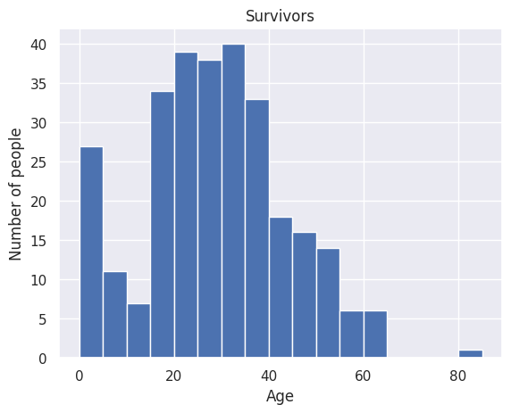

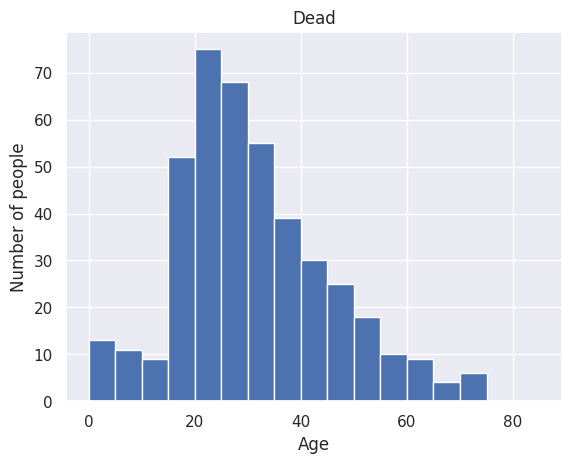

```python
data[data['Survived'] == 1].hist(column='Age', bins=range(0, 90, 5))
ax = plt.gcf().gca()
ax.set_title('Survivors')
ax.set_xlabel('Age')
ax.set_ylabel('Number of people')

data[data['Survived'] == 0].hist(column='Age', bins=range(0, 90, 5))
ax = plt.gcf().gca()
ax.set_title('Dead')
ax.set_xlabel('Age')
ax.set_ylabel('Number of people')
plt.show()
```

```python
# проверка среднего возраста
data[data['Survived'] == 1]['Age'].mean()
```

```
28.343689655172415
```

```python
data[data['Survived'] == 0]['Age'].mean()
```

```
30.62617924528302
```

- **Средний возраст погибших выше** из-за большого числа выживших детей

**8. Как отличается средний возраст мужчин / женщин в зависимости от класса обслуживания? Выберите верные утверждения:**

- В среднем мужчины 1-го класса старше 40 лет ✅
- В среднем женщины 1-го класса старше 40 лет ❌
- Мужчины всех классов в среднем старше женщин того же класса ✅
- В среднем люди в 1 классе старше, чем во 2-ом, а те старше представителей 3-го класса ✅

```python
# Ваш код здесь

for pclass in range(1, 4):
    male_avg_age = data[(data['Sex'] == 'male') & (data['Pclass'] == pclass)]['Age'].mean()
    female_avg_age = data[(data['Sex'] == 'female') & (data['Pclass'] == pclass)]['Age'].mean()
    print(f'Male avg. age in Pclass {pclass}: \t{male_avg_age}')
    print(f'Female avg. age in Pclass {pclass}: \t{female_avg_age}')
```

```
Male avg. age in Pclass 1: 	41.28138613861386
Female avg. age in Pclass 1: 	34.61176470588235
Male avg. age in Pclass 2: 	30.74070707070707
Female avg. age in Pclass 2: 	28.722972972972972
Male avg. age in Pclass 3: 	26.507588932806325
Female avg. age in Pclass 3: 	21.75
```